# TD1 - 30/03/21 - Simulation et Monte Carlo

- **Exercice 1 :** RANDU
- **Exercice 2 :** Rejet et loi de Laplace
- **Exercice 3 :** Box-Muller amélioré

## Exercice 1 :

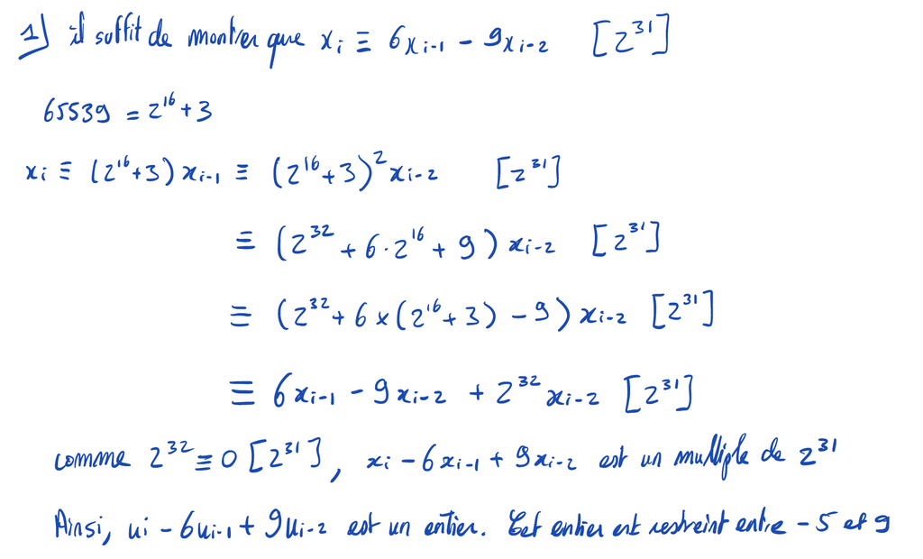

### 1.2

```python
import numpy as np

def randu(x0, n):
    """
    input :
      x0 une valeur deterministe a fixer,
      n la taille de la liste que l on souhaite avoir
    output :
      u = (u_1, ..., u_n)
    """
    U = []
    x = x0
    for i in range(n):
        a = (2 ** 16 + 3) * x
        x = a % (2 ** 31)
        U.append(x / (2 ** 31) )
    U = np.array(U)
    return U
```

```python
x0 = 2000
n = 20000
u = randu(x0, n)
```

Mettons en evidence les 9 hyperplans (sur les 15)

```python
x = u[:-2]
y = u[1:-1]
z = u[2:]
```

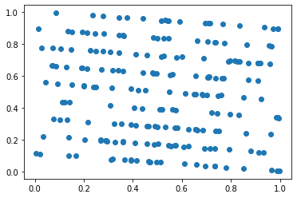

```python
from matplotlib import pyplot as plt
%matplotlib inline

filtre = (y <= 0.51) * (y >= 0.5)
plt.figure()
plt.scatter(z[filtre], x[filtre])
plt.show()
```

L'objectif d'un generateur (pseudo-)aleatoire est de generer des v.a.i.i.d mais nous voyons ici que les echantillons sont dependants entre eux ! en sachant que beaucoup d'autres generateurs alea sont programmés a partir du generateur uniforme ... nous voulons a tout prix avoir un generateur uniforme performant !

**ps :** Avant les années 1970, ce générateur était utilisé pour générer des distributions uniformes. La fiabilité des papiers utilisant ce générateur ou des applications directes est mise en doute.

### 1.2 bis

Mettons en evidence les 6 hyperplans restants

```python
filtre = (y <= 0.51) * (y >= 0.5)
plt.figure()
plt.scatter(z[filtre], x[filtre])
plt.show()
```

[output not shown]

### 1.3

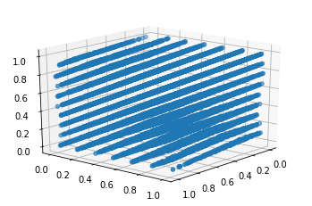

```python
from mpl_toolkits.mplot3d import Axes3D

fig = plt.figure()
ax = fig.add_subplot(111, projection="3d")
ax.scatter3D(z, y, x)
ax.view_init(20, 40)
plt.show()
```

### 1.4

```python
u_bits = (2 ** 31 * u).astype(int)

for i in range(15):
    print("{0:b}".format(u_bits[i]))
```

```
111110100000001011101110000
101110111000000100011001010000
1010010111100001101001011110000
1001011110000100111100011010000
1011100000101110110101001110000
1111110101101100011111101010000
111011011100101011110111110000
1110000010010000011100111010000
1010101010001010110101110000
1001101011010100000100001010000
1110000100011100001100011110000
1101010100110100100101011010000
1010100111101110000001110000
10011001010000101010000
100010001101011110001111110000
```

Pour le generateur RANDU nous pouvons visuellement voir la faible periode des bits de poids faibles des x_i. La fonction "runif" de R (ou numpy.random.rand de Python) ne possede pas ce phenomène. (voir la définition du generateur de Mersenne-Twister)

```python
ubis = np.random.rand(20000)
```

```python
u_bits = (2 ** 31 * ubis).astype(int)

for i in range(15):
    print("{0:b}".format(u_bits[i]))
```

```
1110011111111010000010100111001
101110110111010100000001001101
1000011101011111010001110101100
10110100000000011011100101110
1010100110010111000000000001111
100111001111010111010000001111
111000110100100110101010011110
1101010111111101110110100011000
10000010000010000101011001100
1101110001110000111100101101001
1101111100000111011111001111101
100110110100111101110000010100
1110000000110001001000111111001
1101010001000110111000111010101
110111001101110001001001000111
```

### 1.5 :)